# Lipidr_results_Cow

#Libraries

```r
library(readxl)
library(visdat)
library(data.table)
library(tidyverse)
library(reshape2)
#graphics
library(ggplot2)
library(plotly)

#PCA
library(FactoMineR)
library(factoextra)

#imputation
library(impute)

#Lipidr
library(lipidr)
library(devtools)
library(stats)
```

# Study

In this workflow we will analyze a data set from Nutrilip experiment

TAG and Polar lipids (PL) in Cows and Goats by (Fougère et al. 2021)

Samples: • 12 Cows • 12 Goats

4 diets (CTL, COS, MAP, HOP), 48 samples poled by period and diet, 3 animals per period and diet finally obtention of 16 samples and 3 mL of milk per sample. Treatments: Both cows and goats were feed with the 4 treatments over 28-d applying the Latin square design. (Table 2). CTL milk was dominated by molecular species of TAG with 36 to 52 carbons, 93% for cows and 94% for goats. Saturated, monosaturated and PUFA (poly-unsaturated fatty acids) TAG were founded in similar amounts in milk for both ruminant species 33%, 34%, 39% for cows and 37%, 32% 31% for goats.

• CTL: based in corn 53.2% concentrate DM, soy 13.8%, dehydrated alphalpha 27.5%, cane molasses 3.7%, dicalcium vitamin 0.2%. • COS: Corn oil and Starch; • MAP: Marine algae powder. • HOP: Hydrogenated palm oil.

The data used are previously imputed and normalized by Log2

# Data preparation

The code below shows the data set from the experiment AQ664-Nutrilip, the aim is to statistically analyze the data whit the bioinformatic tool Lipir

## Import datasets from AQ664_Results_Lait.xlsx

```r
#import data set
data_clin_cow <- read.csv("data_clin_cow.csv",sep=',')
data_matrix_cow=read.csv("data_matrix_cow.csv")

rownames(data_matrix_cow)=data_matrix_cow[,1]
data_matrix_cow=data_matrix_cow[,-1]

colnames(data_matrix_cow)=gsub('\\.', "-", colnames(data_matrix_cow))

d <- as_lipidomics_experiment(data_matrix_cow)
d <- add_sample_annotation(d, data_clin_cow)
```

# Data quality check

To ensure the quality of the data we take a look at total lipid intensity as bar chart or distribution of samples as a box-plot. It should be noted that our data were previously imputed and normalized with a log2 transformation, so a good quality of data will be observed.

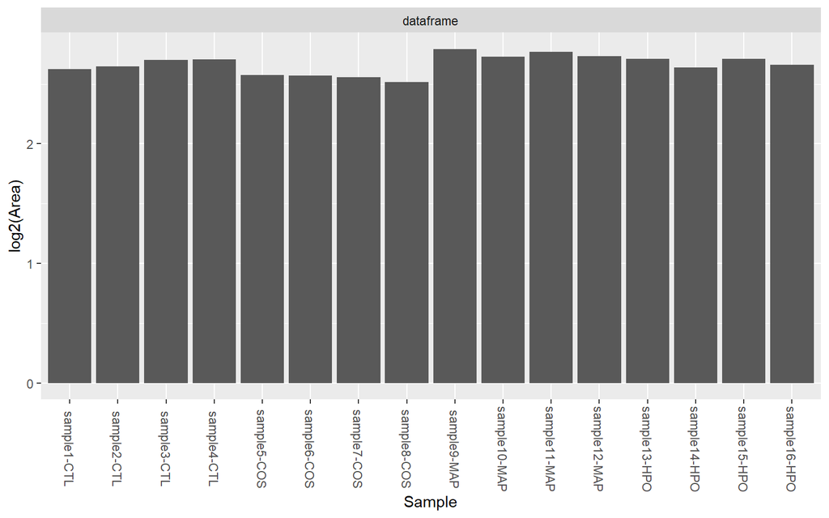

```r
plot_samples(d, type = "tic", log = TRUE)
```

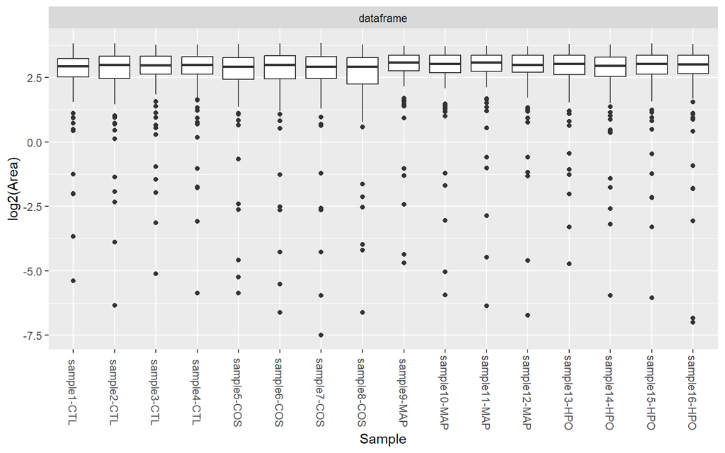

```r
plot_samples(d, "boxplot")
```

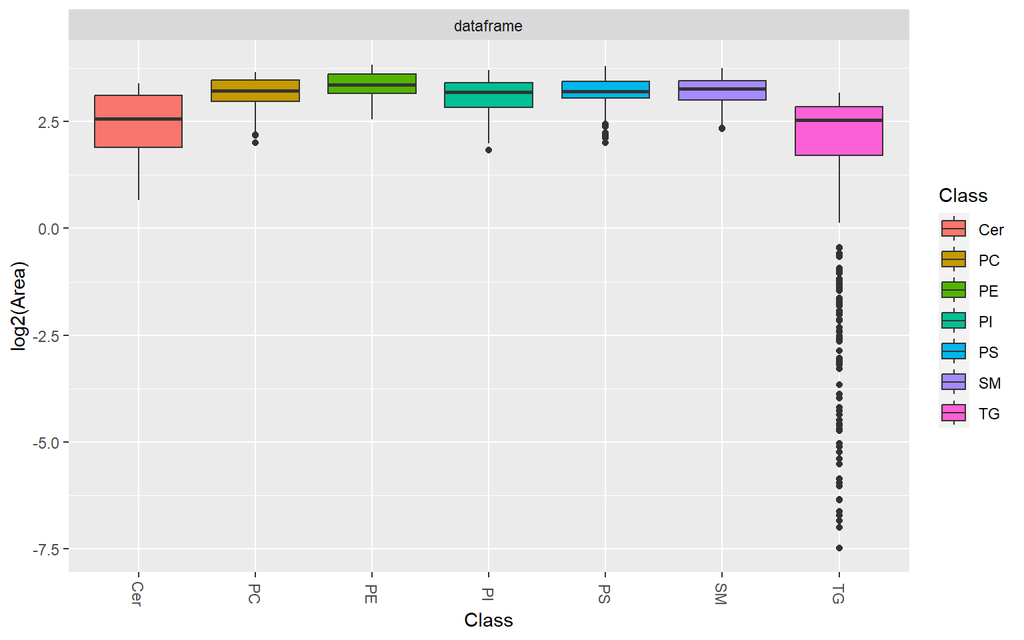

```r
plot_lipidclass(d, "boxplot")
```

# Multivariate analysis

## PCA

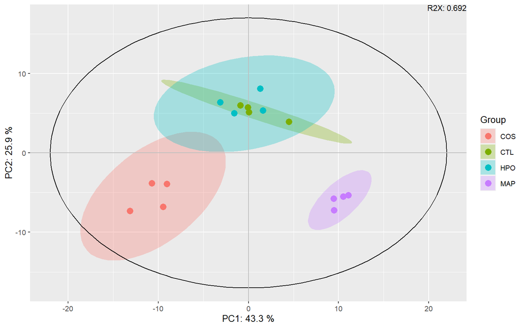

```r
mvaresults = mva(d, measure="Area", method="PCA")
plot_mva(mvaresults, color_by="diet", components = c(1,2))
```

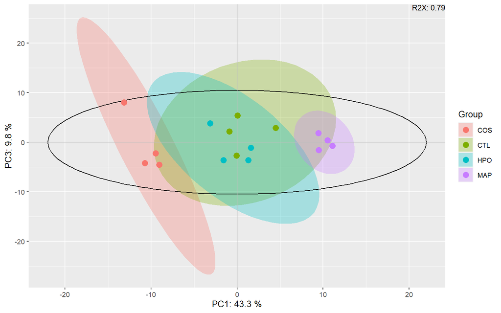

```r
plot_mva(mvaresults, color_by="diet", components = c(1,3))
```

## Orthogonal multivariate analysis

OPLS and OPLS-DA can be performed to determine which lipids are associated with a group (y-variable) of interest.

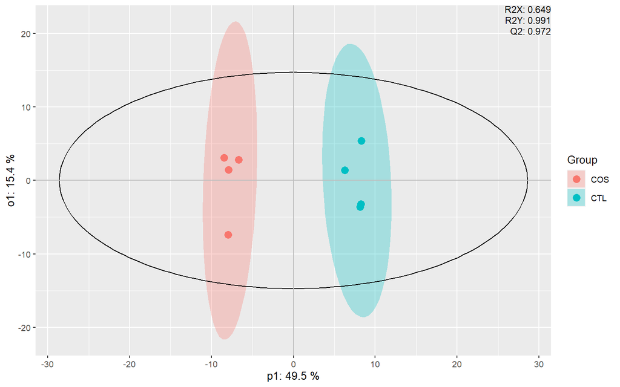

```r
mvaresults = mva(d, method = "OPLS-DA", group_col = "diet", groups=c("COS", "CTL"))
plot_mva(mvaresults, color_by="diet")
```

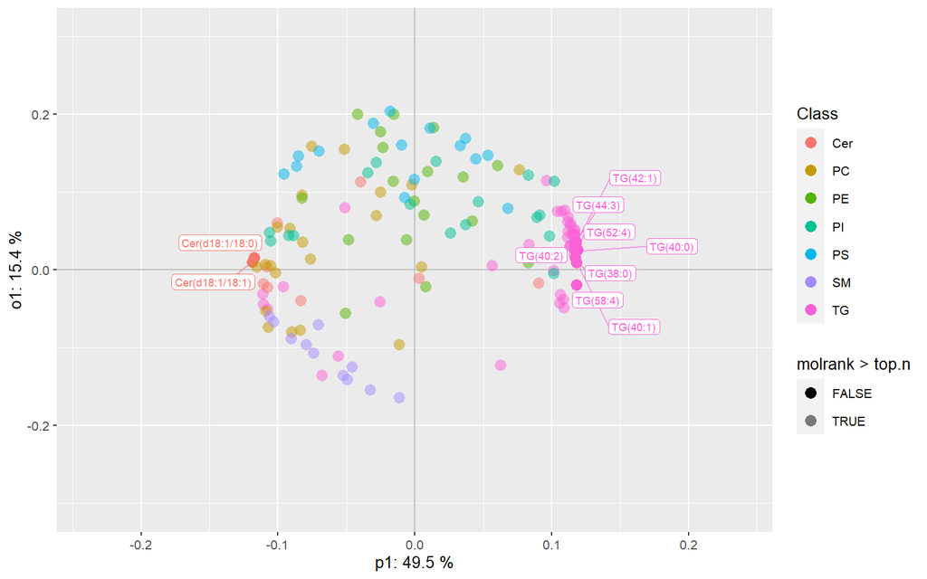

```r
plot_mva_loadings(mvaresults, color_by="Class", top.n=10)
```

```r
top_lipids(mvaresults, top.n=10)
```

```
##     filename        Molecule    clean_name ambig not_matched  istd class_stub
## 1  dataframe        TG(52:4)       TG 52:4 FALSE       FALSE FALSE         TG
## 2  dataframe Cer(d18:1/18:1) Cer 18:1/18:1 FALSE       FALSE FALSE        Cer
## 3  dataframe        TG(40:1)       TG 40:1 FALSE       FALSE FALSE         TG
## 4  dataframe        TG(58:4)       TG 58:4 FALSE       FALSE FALSE         TG
## 5  dataframe        TG(40:0)       TG 40:0 FALSE       FALSE FALSE         TG
## 6  dataframe        TG(44:3)       TG 44:3 FALSE       FALSE FALSE         TG
## 7  dataframe        TG(42:1)       TG 42:1 FALSE       FALSE FALSE         TG
## 8  dataframe Cer(d18:1/18:0) Cer 18:1/18:0 FALSE       FALSE FALSE        Cer
## 9  dataframe        TG(38:0)       TG 38:0 FALSE       FALSE FALSE         TG
## 10 dataframe        TG(40:2)       TG 40:2 FALSE       FALSE FALSE         TG
##    chain1 l_1 s_1 chain2 l_2 s_2 chain3 l_3 s_3 chain4 l_4 s_4 total_cl
## 1    52:4  52   4         NA  NA         NA  NA         NA  NA       52
## 2    18:1  18   1   18:1  18   1         NA  NA         NA  NA       36
## 3    40:1  40   1         NA  NA         NA  NA         NA  NA       40
```

[output cut: 18 more lines]

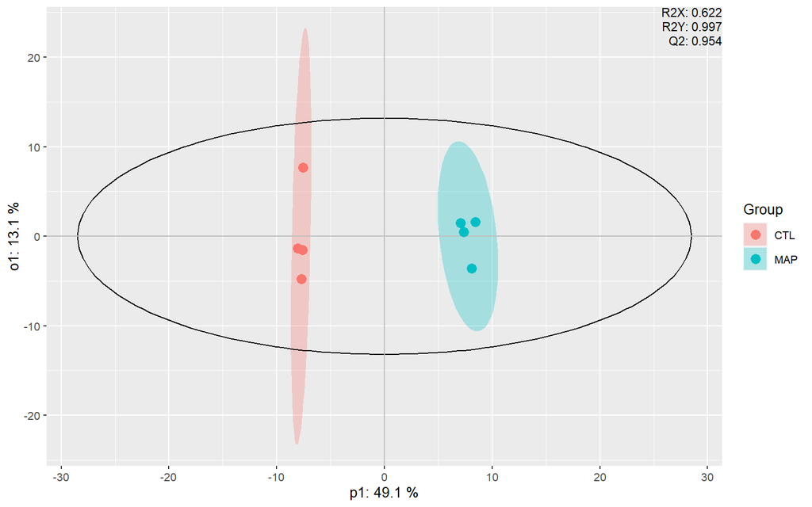

```r
mvaresults = mva(d, method = "OPLS-DA", group_col = "diet", groups=c("MAP", "CTL"))
plot_mva(mvaresults, color_by="diet")
```

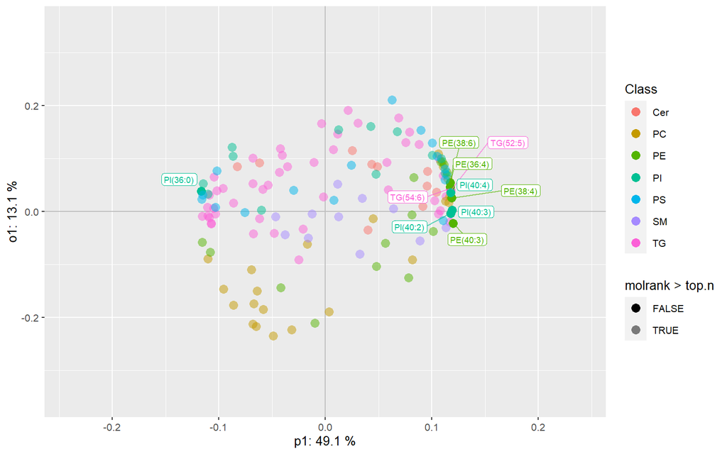

```r
plot_mva_loadings(mvaresults, color_by="Class", top.n=10)
```

```r
top_lipids(mvaresults, top.n=10)
```

```
##     filename Molecule clean_name ambig not_matched  istd class_stub chain1 l_1
## 1  dataframe PE(40:3)    PE 40:3 FALSE       FALSE FALSE         PE   40:3  40
## 2  dataframe PI(40:3)    PI 40:3 FALSE       FALSE FALSE         PI   40:3  40
## 3  dataframe PE(38:4)    PE 38:4 FALSE       FALSE FALSE         PE   38:4  38
## 4  dataframe TG(52:5)    TG 52:5 FALSE       FALSE FALSE         TG   52:5  52
## 5  dataframe PI(40:2)    PI 40:2 FALSE       FALSE FALSE         PI   40:2  40
## 6  dataframe PI(40:4)    PI 40:4 FALSE       FALSE FALSE         PI   40:4  40
## 7  dataframe PE(38:6)    PE 38:6 FALSE       FALSE FALSE         PE   38:6  38
## 8  dataframe PE(36:4)    PE 36:4 FALSE       FALSE FALSE         PE   36:4  36
## 9  dataframe TG(54:6)    TG 54:6 FALSE       FALSE FALSE         TG   54:6  54
## 10 dataframe PI(36:0)    PI 36:0 FALSE       FALSE FALSE         PI   36:0  36
##    s_1 chain2 l_2 s_2 chain3 l_3 s_3 chain4 l_4 s_4 total_cl total_cs Class
## 1    3         NA  NA         NA  NA         NA  NA       40        3    PE
## 2    3         NA  NA         NA  NA         NA  NA       40        3    PI
## 3    4         NA  NA         NA  NA         NA  NA       38        4    PE
```

[output cut: 18 more lines]

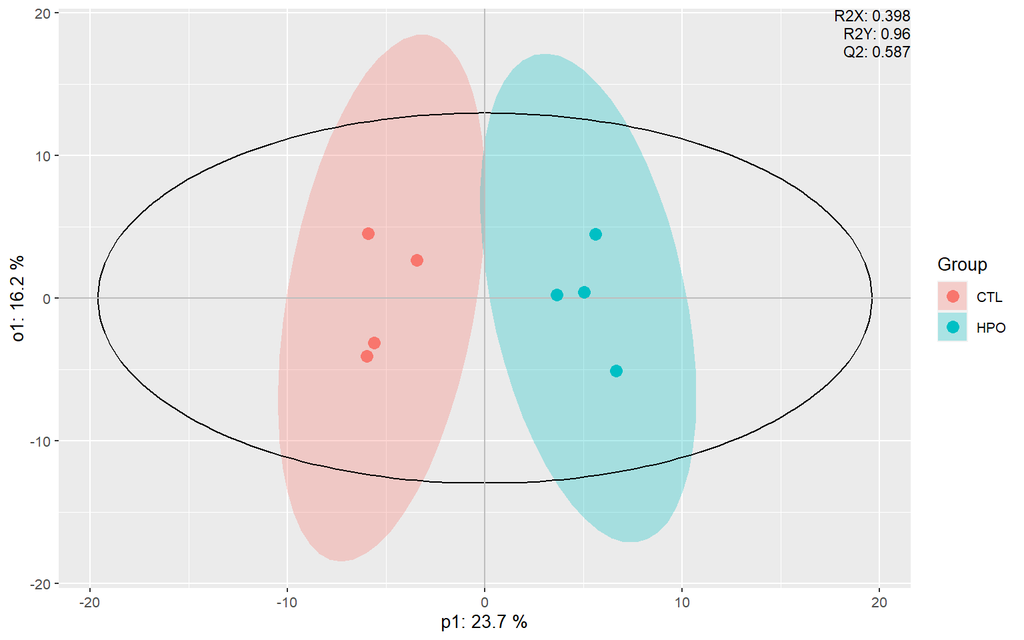

```r
mvaresults = mva(d, method = "OPLS-DA", group_col = "diet", groups=c("HPO", "CTL"))
plot_mva(mvaresults, color_by="diet")
```

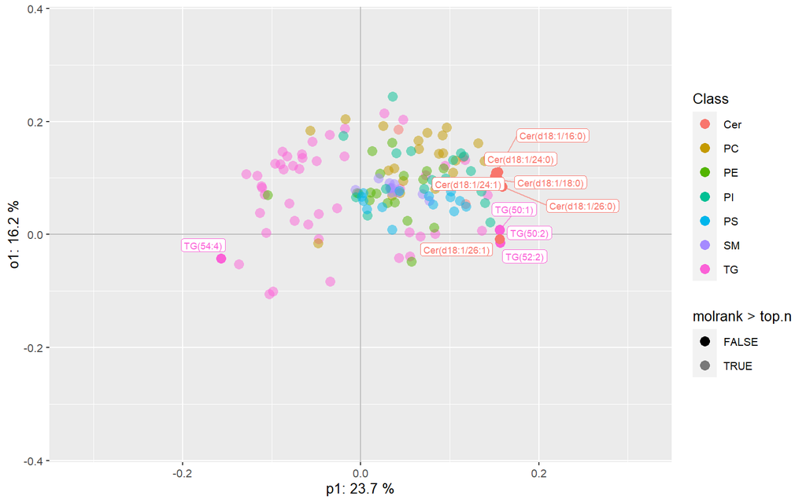

```r
plot_mva_loadings(mvaresults, color_by="Class", top.n=10)
```

```r
top_lipids(mvaresults, top.n=10)
```

```
##     filename        Molecule    clean_name ambig not_matched  istd class_stub
## 1  dataframe Cer(d18:1/26:0) Cer 18:1/26:0 FALSE       FALSE FALSE        Cer
## 2  dataframe        TG(54:4)       TG 54:4 FALSE       FALSE FALSE         TG
## 3  dataframe        TG(52:2)       TG 52:2 FALSE       FALSE FALSE         TG
## 4  dataframe        TG(50:1)       TG 50:1 FALSE       FALSE FALSE         TG
## 5  dataframe        TG(50:2)       TG 50:2 FALSE       FALSE FALSE         TG
## 6  dataframe Cer(d18:1/26:1) Cer 18:1/26:1 FALSE       FALSE FALSE        Cer
## 7  dataframe Cer(d18:1/18:0) Cer 18:1/18:0 FALSE       FALSE FALSE        Cer
## 8  dataframe Cer(d18:1/24:0) Cer 18:1/24:0 FALSE       FALSE FALSE        Cer
## 9  dataframe Cer(d18:1/16:0) Cer 18:1/16:0 FALSE       FALSE FALSE        Cer
## 10 dataframe Cer(d18:1/24:1) Cer 18:1/24:1 FALSE       FALSE FALSE        Cer
##    chain1 l_1 s_1 chain2 l_2 s_2 chain3 l_3 s_3 chain4 l_4 s_4 total_cl
## 1    18:1  18   1   26:0  26   0         NA  NA         NA  NA       44
## 2    54:4  54   4         NA  NA         NA  NA         NA  NA       54
## 3    52:2  52   2         NA  NA         NA  NA         NA  NA       52
```

[output cut: 18 more lines]

# Differential analysis

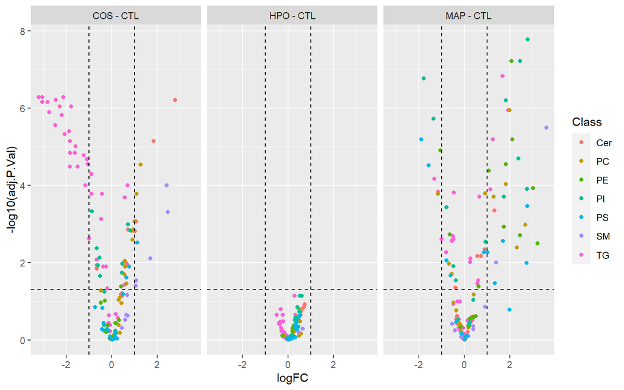

```r
# Analyse comparaison
de_results <- de_analysis(
  d,
  COS-CTL,
  MAP-CTL,
  HPO - CTL,
  measure = "Area"
)

#significant lipids
sig_lipids <- significant_molecules(de_results)


# volcano plot sig lipids
plot_results_volcano(de_results)
```

## Export significant lipids

```r
write.csv(sig_lipids$`COS - CTL`,file="Sig_COS_CTL.csv",
          row.names=FALSE)

write.csv(sig_lipids$`MAP - CTL`,file="Sig_MAP_CTL.csv",
          row.names=FALSE)

write.csv(sig_lipids$`MAP - CTL`,file="Sig_HPO_CTL.csv",
          row.names=FALSE)
```

# Enrichment analysis

lipidr automatically generates sets of lipids based on lipid class, total chain length and unsaturation. Measured lipids are then ranked by their fold change, or p-value using results from differential analysis.in this case we use the Fold change as a parametre

```r
#sets of libid based on it lipid class
enrich_results = lsea(de_results, rank.by = "logFC")
significant_lipidsets(enrich_results)
```

```
## $`COS - CTL`
##  [1] "Class_TG"    "total_cs_0"  "Class_PC"    "total_cl_34" "Class_SM"
##  [6] "total_cl_36" "total_cl_44" "Class_Cer"   "total_cs_2"  "total_cl_48"
## [11] "total_cl_46"
##
## $`HPO - CTL`
## [1] "Class_TG"   "Class_Cer"  "total_cs_1"
##
## $`MAP - CTL`
## [1] "total_cl_40" "total_cs_1"  "total_cs_6"
```

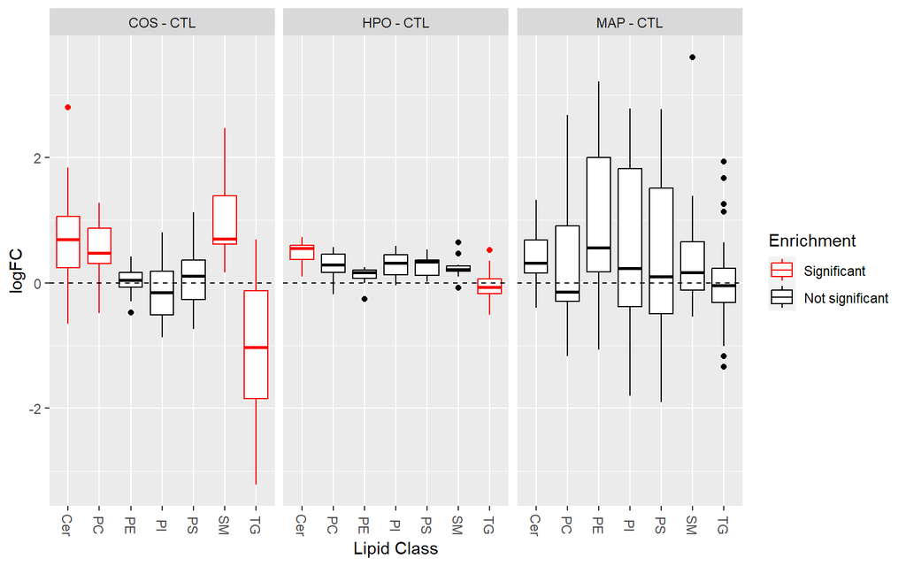

```r
#enrichment analysis by lipid class
plot_enrichment(de_results, significant_lipidsets(enrich_results), annotation="class")
```

We can observe in the graphics that according with the lipid class, COS and HPO have a significant enrichment in relation with the control

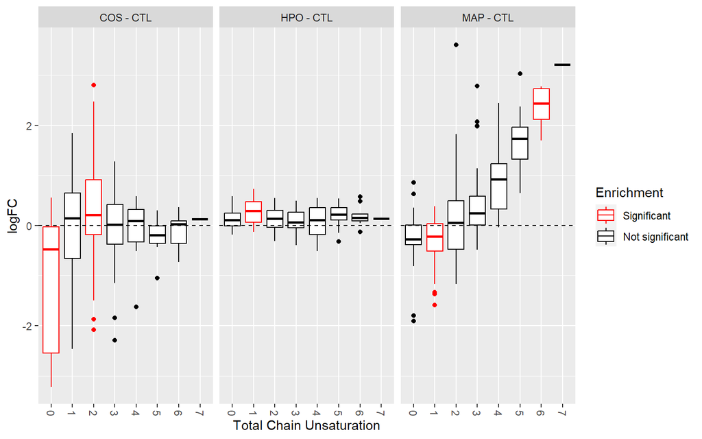

```r
#enrichment analysis by chain unsaturation
plot_enrichment(de_results, significant_lipidsets(enrich_results), annotation="unsat")
```

We can observe in the graphics that according with the total chain un-saturation the 3 nutritional regiments have a significant enrichment in relation with the control

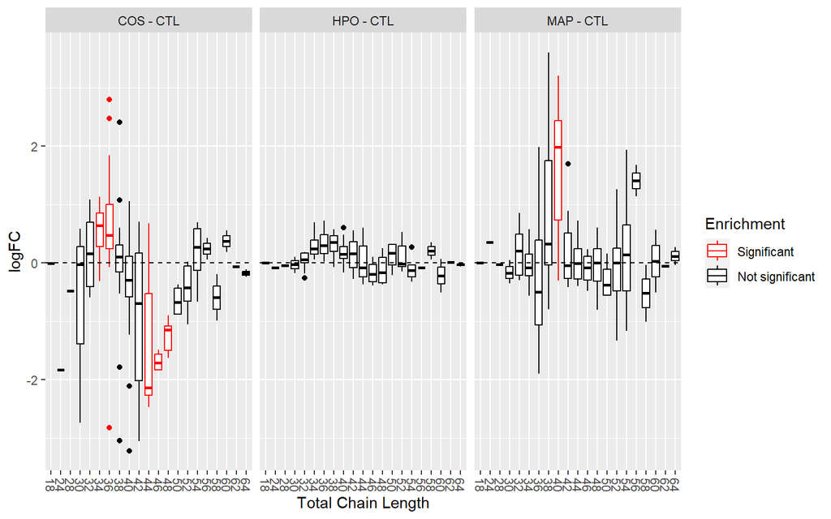

```r
#enrichment by chain lenght
plot_enrichment(de_results, significant_lipidsets(enrich_results), annotation="length")
```

We can observe in the graphics that according with the total chain length the nutritional regiments COS and MAP have a significant enrichment in relation with the control

# Contrast analyse

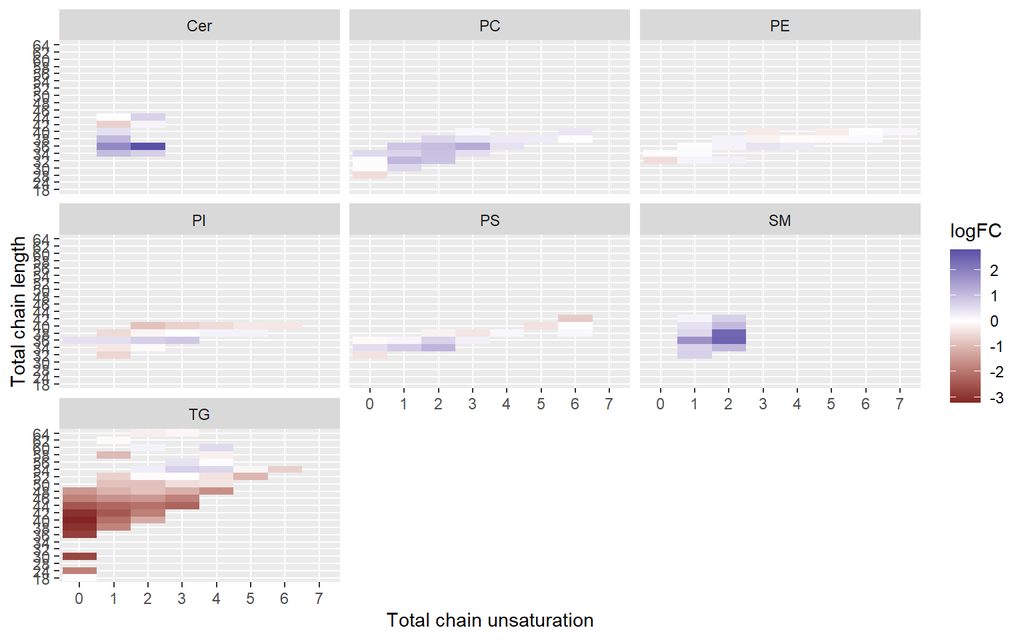

```r
#results chain distribution

#results COS - CTL
plot_chain_distribution(de_results,contrast="COS - CTL", measure = "logFC")
```

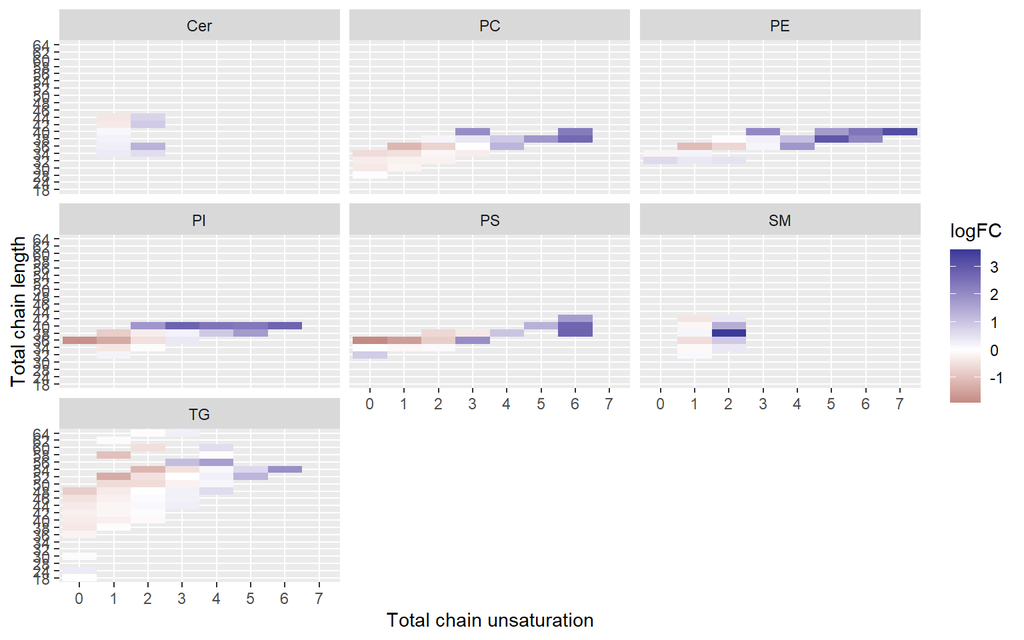

```r
#results MAP - CTL
plot_chain_distribution(de_results,contrast="MAP - CTL")
```

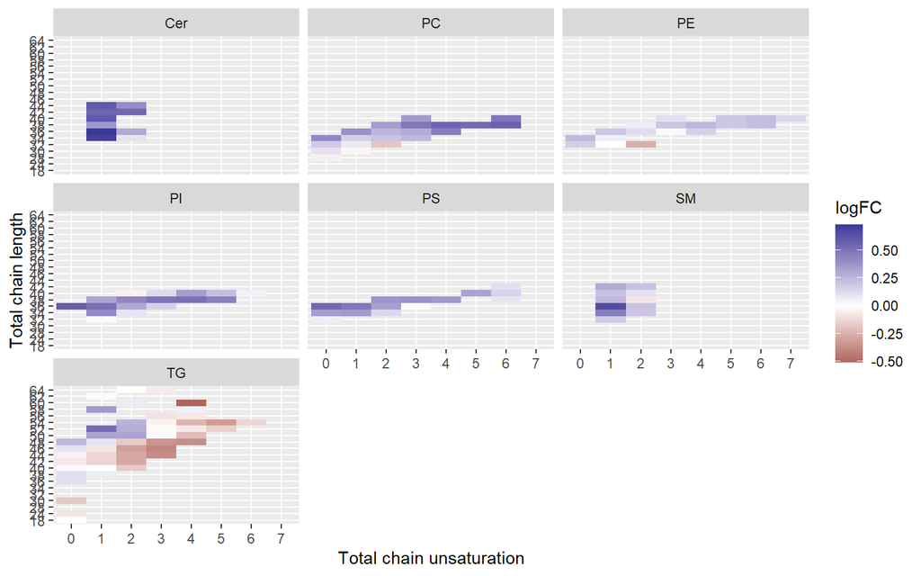

```r
#results HPO -  CTL
plot_chain_distribution(de_results,contrast="HPO - CTL")
```

Plot fold changes of lipids per class showing total chain lengths and unsaturations. Number on the plot indicate multiple lipids measured with the same chain properties.

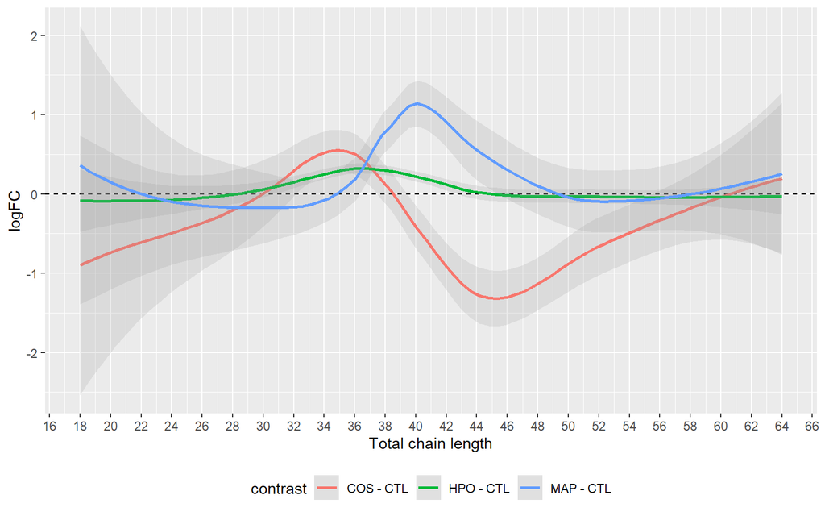

```r
#lipid chain analysis
plot_trend(de_results)
```

Plot showing lipid chain analysis